# faux

[figure not shown]

It is useful to be able to simulate data with a specified structure. The `faux` package provides some functions to make this process easier. See the vignettes for more details.

## Installation

You can install the released version of faux from [CRAN](https://CRAN.R-project.org) with:

```r
install.packages("faux")
```

And the development version from [GitHub](https://github.com/debruine/faux) with:

```r
# install.packages("devtools")
devtools::install_github("debruine/faux")
```

## Quick overview

### Simulate data for a factorial design

See the Simulate by Design vignette for more details.

```r
between <- list(pet = c(cat = "Cat Owners",
                        dog = "Dog Owners"))
within <- list(time = c("morning",
                        "noon",
                        "evening",
                        "night"))
mu <- data.frame(
  cat    = c(10, 12, 14, 16),
  dog    = c(10, 15, 20, 25),
  row.names = within$time
)
df <- sim_design(within, between,
                 n = 100, mu = mu,
                 sd = 5, r = .5)
```

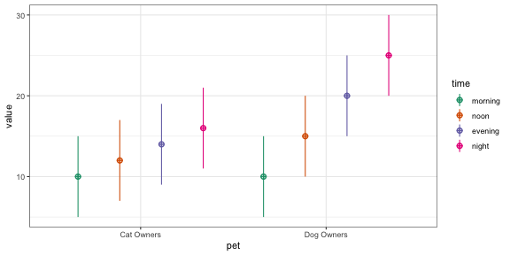

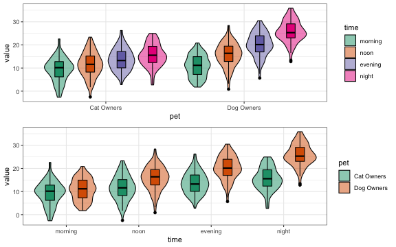

```r
p1 <- plot_design(df)
p2 <- plot_design(df, "pet", "time")

cowplot::plot_grid(p1, p2, nrow = 2, align = "v")
```

### Simulate new data from an existing data table

See the Simulate from Existing Data vignette for more details.

```r
new_iris <- sim_df(iris, 50, between = "Species")
```

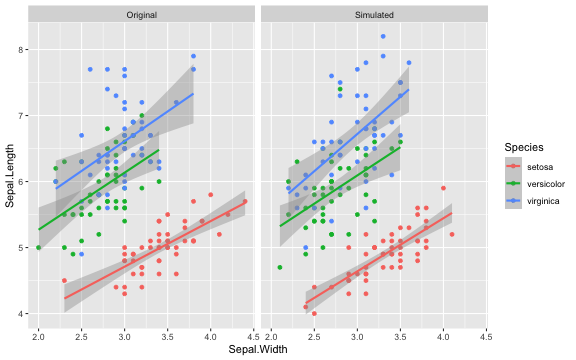

### Simulate data for a mixed design

```r
# simulate 20 classes with 20 to 30 students per class
data <- add_random(class = 20) %>%
  add_random(student = sample(20:30, 20, replace = TRUE),
             .nested_in = "class") %>%
  add_between(.by = "class",
              school_type = c("private","public"),
              .prob = c(5, 15)) %>%
  add_between(.by = "student",
              gender = c("M", "F", "NB"),
              .prob = c(.49, .49, .02))
```

| school_type | gender | n |
| --- | --- | --- |
| private | M | 58 |
| private | F | 65 |
| private | NB | 2 |
| public | M | 164 |
| public | F | 191 |
| public | NB | 7 |

## Other simulation packages

I started this project as a collection of functions I was writing to help with my own work. It's one of many, many simulation packages in R; here are some others. I haven't used most of them, so I can't vouch for them, but if faux doesn't meet your needs, one of these might.

- [SimDesign](https://cran.r-project.org/web/packages/SimDesign/vignettes/SimDesign-intro.html): generate, analyse and summarise data from models or probability density functions
- [simstudy](https://kgoldfeld.github.io/simstudy/): Simulation of Study Data
- simr: Power Analysis of Generalised Linear Mixed Models by Simulation
- simulator: streamlines the process of performing simulations by creating a common infrastructure that can be easily used and reused across projects
- lsasim: Simulate large scale assessment data
- [simmer](https://r-simmer.org/): Trajectory-based Discrete-Event Simulation (DES
- [parSim](https://cran.r-project.org/web/packages/parSim/): Parallel Simulation Studies